# Mutual Rank eQTL overlap

## Background

Rob Baker et al fit growth parameters to B. rapa growth data and then used those to do function-value-trait QTL mapping.

I used those same parameters and queried a mutual rank (MR) gene expression network to find genes that were in a networks associated with these growth paramters. This was done separeately for the CR and UN environments. I looked for overalp between those MR-associated genes and growth parameters.

The goal now is to find the trans eQTL for each of the MR-growth associated genes and ask if the trans eQTL overlap with the growth/function-value QTL. I think I am only going to take the top eQTL for each.

## Methodology

For each gene in a MR network with a growth parameter query the eQTL database to find its trans eQTL regions. Then compare overlaps between those and the growth QTL.

## Load the libraries and data

Libraries

```r
library(tidyverse)
library(stringr)
library(magrittr)
library(qtl)
```

Growth QTL

```r
QTLgenes <- read_csv("~/Box Sync/BrapaNetworks/Heigh2012_uniquegenes.csv")[,-1]
summary(QTLgenes)
```

```
     .id                name              chrom               start               end             subject
 Length:490         Length:490         Length:490         Min.   : 1520214   Min.   : 1521869   Length:490
 Class :character   Class :character   Class :character   1st Qu.: 3115802   1st Qu.: 3118228   Class :character
 Mode  :character   Mode  :character   Mode  :character   Median : 6858619   Median : 6860980   Mode  :character
                                                          Mean   : 7242444   Mean   : 7244888
                                                          3rd Qu.:11731390   3rd Qu.:11733108
                                                          Max.   :12299413   Max.   :12300179
     AGI             At_symbol         At_description        perc_ID        aln_length        mismatch
 Length:490         Length:490         Length:490         Min.   :65.86   Min.   :  50.0   Min.   :  5.0
 Class :character   Class :character   Class :character   1st Qu.:80.36   1st Qu.: 517.0   1st Qu.: 66.0
 Mode  :character   Mode  :character   Mode  :character   Median :84.95   Median : 957.5   Median :113.0
                                                          Mean   :83.81   Mean   :1098.8   Mean   :142.5
                                                          3rd Qu.:88.04   3rd Qu.:1438.0   3rd Qu.:186.8
                                                          Max.   :94.48   Max.   :5572.0   Max.   :754.0
    gap_open          qstart            qend          sstart            send             eval
 Min.   : 0.000   Min.   :   1.0   Min.   :  71   Min.   :   1.0   Min.   :   1.0   Min.   :0.000e+00
 1st Qu.: 1.000   1st Qu.:  32.0   1st Qu.: 711   1st Qu.:   1.0   1st Qu.:   1.0   1st Qu.:0.000e+00
 Median : 3.000   Median : 176.0   Median :1128   Median : 386.0   Median : 499.5   Median :0.000e+00
 Mean   : 5.051   Mean   : 250.4   Mean   :1330   Mean   : 680.2   Mean   : 713.0   Mean   :2.062e-09
 3rd Qu.: 7.000   3rd Qu.: 291.0   3rd Qu.:1724   3rd Qu.:1107.8   3rd Qu.:1101.8   3rd Qu.:0.000e+00
 Max.   :52.000   Max.   :2719.0   Max.   :5737   Max.   :5392.0   Max.   :5539.0   Max.   :1.010e-06
     score
 Min.   :  55.4
 1st Qu.: 489.0
 Median :1001.0
 Mean   :1212.3
 3rd Qu.:1548.8
 Max.   :7288.0
```

```r
QTLgenes
```

| .id | name | chrom | start | end | subject | AGI | At_symbol | At_description | perc_ID | aln_length | mismatch | gap_open | qstart | qend | sstart | send | eval | score |
| --- | --- | --- | --- | --- | --- | --- | --- | --- | --- | --- | --- | --- | --- | --- | --- | --- | --- | --- |
| QTL1 | Bra029075 | A03 | 6226990 | 6229080 | AT5G53320.1 | AT5G53320 | NA | NA | 84.361 | 1816 | 247 | 10 | 99 | 1891 | 1 | 1802 | 0.00e+00 | 1983.0 |
| QTL1 | Bra029076 | A03 | 6229955 | 6231513 | AT5G53300.1 | AT5G53300 | UBC10 | Encodes a ubiquitin conjugating enzyme. | 93.905 | 443 | 27 | 0 | 181 | 623 | 1 | 443 | 0.00e+00 | 677.0 |
| QTL1 | Bra029079 | A03 | 6250806 | 6252396 | AT5G53290.1 | AT5G53290 | CRF3 | encodes a member of the ERF (ethylene response factor) subfamily B-5 of ERF/AP2 transcription factor family. The protein contains one AP2 domain. There are 7 members in this subfamily. | 75.140 | 1074 | 187 | 16 | 309 | 1315 | 5 | 1065 | 0.00e+00 | 733.0 |
| QTL1 | Bra029080 | A03 | 6257907 | 6260231 | AT5G58230.1 | AT5G58230 | ATMSI1;MEE70;MSI1 | Encodes a WD-40 repeat containing protein that functions in chromatin assembly as part of the CAF1 and FIE complex. Mutants exhibit parthenogenetic development that includes proliferation of unfertili… | 84.091 | 176 | 28 | 0 | 73 | 248 | 274 | 449 | 3.28e-48 | 192.0 |
| QTL1 | Bra029081 | A03 | 6271022 | 6278156 | AT5G02050.1 | AT5G02050 | NA | NA | 78.033 | 305 | 58 | 3 | 385 | 683 | 496 | 797 | 2.09e-63 | 242.0 |
| QTL1 | Bra029083 | A03 | 6284270 | 6284937 | AT5G02050.1 | AT5G02050 | NA | NA | 79.853 | 273 | 49 | 1 | 282 | 548 | 522 | 794 | 1.41e-64 | 246.0 |
| QTL1 | Bra029084 | A03 | 6287138 | 6288184 | AT5G53280.1 | AT5G53280 | PDV1 | An integral outer envelope membrane protein (as its homolog PDV2), component of the plastid division machinery. Similar to ARC5, PDV1 localized to a discontinuous ring at the division site in wild-typ… | 80.352 | 738 | 118 | 8 | 55 | 789 | 723 | 10 | 0.00e+00 | 666.0 |
| QTL1 | Bra029085 | A03 | 6290639 | 6291247 | AT5G53260.1 | AT5G53260 | NA | NA | 80.980 | 510 | 91 | 2 | 8 | 517 | 8 | 511 | 1.22e-134 | 479.0 |
| QTL1 | Bra029086 | A03 | 6292181 | 6293025 | AT5G53250.1 | AT5G53250 | AGP22;ATAGP22 | NA | 90.625 | 192 | 18 | 0 | 224 | 415 | 192 | 1 | 2.06e-70 | 266.0 |
| QTL1 | Bra029087 | A03 | 6293054 | 6295145 | AT5G53220.1 | AT5G53220 | NA | NA | 71.181 | 1152 | 206 | 21 | 285 | 1358 | 1107 | 4 | 1.87e-170 | 600.0 |

[output cut: 480 more lines]

MR genes from UN

```r
MR_UN_genes <- read_csv("~/Box Sync/BrapaNetworks/MR_UN_graphs_annotation.csv") %>%
  filter(MR_Cutoff <= 50, !duplicated(name)) %>%
  select(MR_Cutoff,name)
MR_UN_genes
```

| MR_Cutoff | name |
| --- | --- |
| 10 | Bra012899 |
| 20 | Bra038899 |
| 20 | Bra006755_Bra006756 |
| 20 | Bra022867 |
| 20 | Bra023009 |
| 20 | Bra025790 |
| 20 | Bra036465 |
| 20 | Bra008566 |
| 20 | Bra008575 |
| 20 | Bra008577 |

[output cut: 47 more lines]

MR genes from CR

```r
MR_CR_genes <- read_csv("~/Box Sync/BrapaNetworks/MR_CR_graphs_annotation.csv") %>%
  filter(MR_Cutoff <= 50, !duplicated(name)) %>%
  select(MR_Cutoff,name)
summary(MR_CR_genes)
```

```
   MR_Cutoff         name
 Min.   :10.00   Length:34
 1st Qu.:30.00   Class :character
 Median :50.00   Mode  :character
 Mean   :39.41
 3rd Qu.:50.00
 Max.   :50.00
```

```r
MR_CR_genes
```

| MR_Cutoff | name |
| --- | --- |
| 10 | Bra009894 |
| 10 | Bra101983 |
| 10 | Bra008797 |
| 20 | Bra100101 |
| 20 | Bra000169 |
| 20 | Bra025790 |
| 20 | Bra009099 |
| 30 | Bra033733 |
| 30 | Bra101960 |
| 30 | Bra007103 |

[output cut: 24 more lines]

eQTL

```r
load("../brassica_eqtl_paper/input/scanone-eqtl-CR.RData")
load("../brassica_eqtl_paper/input/scanone-eqtl-UN.Rdata")
scanone_imp_UN <- scanone_imp_un
```

```r
ls()
```

```
[1] "brass_CR"       "brass_un"       "MR_CR_genes"    "MR_UN_genes"    "QTLgenes"       "scanone_imp_CR"
[7] "scanone_imp_un" "scanone_imp_UN"
```

## Find eQTL intervals

### CR data

Get the scanone data in a nice format for summarizing and plotting

```r
scanone_CR_gather <- scanone_imp_CR %>%
  gather(key = gene, value = LOD, -chr, -pos) %>%
  semi_join(MR_CR_genes,by=c("gene"="name")) # only keep genes in MR networks
```

plot eQTL peaks…

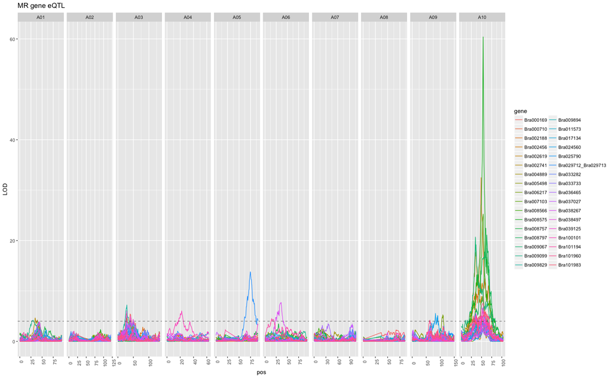

```r
pl.CR <- scanone_CR_gather %>%
  ggplot(aes(x=pos,y=LOD,color=gene)) +
  geom_line() +
  geom_hline(aes(yintercept=4),lty=2,lwd=.5,alpha=.5) +
  facet_grid( ~ chr, scales="free") +
  theme(strip.text.y = element_text(angle=0), axis.text.x = element_text(angle=90)) +
  ggtitle("MR gene eQTL")
pl.CR
```

```r
sig_chromosomes_CR <- scanone_CR_gather %>%
  group_by(gene,chr) %>%
  summarize(pos=pos[which.max(LOD)],LOD=max(LOD)) %>%
  filter(LOD > 4)
sig_chromosomes_CR
```

| gene | chr | pos | LOD |
| --- | --- | --- | --- |
| Bra000169 | A03 | 39.59043 | 5.429423 |
| Bra000169 | A10 | 39.86573 | 4.600880 |
| Bra000710 | A10 | 36.56958 | 4.964236 |
| Bra002188 | A10 | 48.83532 | 32.479796 |
| Bra002456 | A10 | 39.86573 | 13.334944 |
| Bra002619 | A03 | 28.95012 | 6.054670 |
| Bra002741 | A01 | 34.60692 | 4.646917 |
| Bra002741 | A10 | 36.56958 | 18.141150 |
| Bra004889 | A10 | 49.51140 | 5.046675 |
| Bra006217 | A03 | 27.26953 | 4.748767 |

[output cut: 32 more lines]

now for each significant chromosome/trait combo run bayesint

```r
bayesint_list_CR <- apply(sig_chromosomes_CR,1,function(hit) {
  result <- bayesint(scanone_imp_CR[c("chr","pos",hit["gene"])],
                     chr=hit["chr"],
                     lodcolumn = 1,
                     expandtomarkers = TRUE
  )
  colnames(result)[3] <- "LOD"
  result
})
names(bayesint_list_CR) <- sig_chromosomes_CR$gene
bayesint_list_CR <- lapply(bayesint_list_CR,function(x) x %>%
                             as.data.frame() %>%
                             rownames_to_column(var="markername") %>%
                             mutate(chr=as.character(chr))
)
```

```r
bayesint_result_CR <- as.tibble(bind_rows(bayesint_list_CR,.id="gene")) %>%
  select(gene,chr,pos,markername,LOD) %>%
  separate(markername,into=c("chr1","Mbp"),sep="x", convert=TRUE) %>%
  group_by(gene,chr) %>%
  summarize(start=min(Mbp),end=max(Mbp),min_eQTL_LOD=min(LOD),max_eQTL_LOD=max(LOD)) %>%
  #for the high QTL peaks the interval width is 0.  That is overly precise and need to widen those.
  mutate(start=ifelse(start==end,max(0,start-20000),start), end=ifelse(start==end,end+20000,end))
bayesint_result_CR
```

| gene | chr | start | end | min_eQTL_LOD | max_eQTL_LOD |
| --- | --- | --- | --- | --- | --- |
| Bra000169 | A03 | 4296437 | 9829397 | 3.769465 | 5.429423 |
| Bra000169 | A10 | 6430440 | 11852674 | 3.286469 | 4.600880 |
| Bra000710 | A10 | 6430440 | 11852674 | 3.934229 | 4.964236 |
| Bra002188 | A10 | 10983303 | 11003303 | 32.479796 | 32.479796 |
| Bra002456 | A10 | 8389022 | 11427369 | 11.563751 | 13.334944 |
| Bra002619 | A03 | 4610765 | 5439663 | 4.539543 | 6.054670 |
| Bra002741 | A01 | 8682528 | 10144579 | 3.392190 | 4.646917 |
| Bra002741 | A10 | 7916185 | 8389022 | 17.674795 | 18.141150 |
| Bra004889 | A10 | 9620339 | 11427369 | 3.920972 | 5.046675 |
| Bra006217 | A03 | 4240578 | 5068034 | 3.531343 | 4.748767 |

[output cut: 32 more lines]

### UN data

Get the scanone data in a nice format for summarizing and plotting

```r
scanone_UN_gather <- scanone_imp_UN %>%
  gather(key = gene, value = LOD, -chr, -pos) %>%
  semi_join(MR_UN_genes,by=c("gene"="name")) # only keep genes in MR networks
```

plot eQTL peaks…

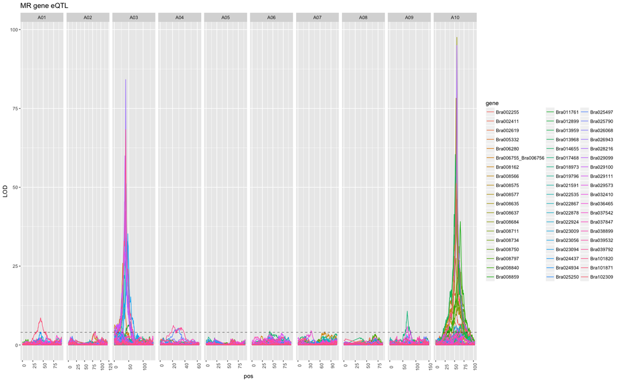

```r
pl.UN <- scanone_UN_gather %>%
  ggplot(aes(x=pos,y=LOD,color=gene)) +
  geom_line() +
  geom_hline(aes(yintercept=4),lty=2,lwd=.5,alpha=.5) +
  facet_grid( ~ chr, scales="free") +
  theme(strip.text.y = element_text(angle=0), axis.text.x = element_text(angle=90)) +
  ggtitle("MR gene eQTL")
pl.UN
```

```r
sig_chromosomes_UN <- scanone_UN_gather %>%
  group_by(gene,chr) %>%
  summarize(pos=pos[which.max(LOD)],LOD=max(LOD)) %>%
  filter(LOD > 4)
sig_chromosomes_UN
```

| gene | chr | pos | LOD |
| --- | --- | --- | --- |
| Bra002255 | A10 | 48.83532 | 17.263514 |
| Bra002411 | A10 | 49.51140 | 7.161845 |
| Bra005332 | A10 | 56.13218 | 82.277772 |
| Bra006280 | A03 | 17.66788 | 5.695366 |
| Bra006280 | A10 | 65.59157 | 4.818954 |
| Bra006755_Bra006756 | A03 | 28.95012 | 25.932565 |
| Bra008162 | A07 | 73.34372 | 4.191937 |
| Bra008566 | A10 | 54.02905 | 27.513491 |
| Bra008575 | A10 | 54.02905 | 68.155456 |
| Bra008577 | A10 | 54.02905 | 78.247563 |

[output cut: 44 more lines]

now for each significant chromosome/trait combo run bayesint

```r
bayesint_list_UN <- apply(sig_chromosomes_UN,1,function(hit) {
  result <- bayesint(scanone_imp_UN[c("chr","pos",hit["gene"])],
                     chr=hit["chr"],
                     lodcolumn = 1,
                     expandtomarkers = TRUE
  )
  colnames(result)[3] <- "LOD"
  result
})
names(bayesint_list_UN) <- sig_chromosomes_UN$gene
bayesint_list_UN <- lapply(bayesint_list_UN,function(x) x %>%
                             as.data.frame(stringsAsFactors=FALSE) %>%
                             rownames_to_column(var="markername") %>%
                             mutate(chr=as.character(chr))
)
```

```r
bayesint_result_UN <- as.tibble(bind_rows(bayesint_list_UN,.id="gene")) %>%
  select(gene,chr,pos,markername,LOD) %>%
  separate(markername,into=c("chr1","Mbp"),sep="x", convert=TRUE) %>%
  group_by(gene,chr) %>%
  summarize(start=min(Mbp),end=max(Mbp),min_eQTL_LOD=min(LOD),max_eQTL_LOD=max(LOD)) %>%
  #for the high QTL peaks the interval width is 0.  That is overly precise and need to widen those.
  mutate(start=ifelse(start==end,max(0,start-20000),start), end=ifelse(start==end,end+20000,end))
bayesint_result_UN
```

| gene | chr | start | end | min_eQTL_LOD | max_eQTL_LOD |
| --- | --- | --- | --- | --- | --- |
| Bra002255 | A10 | 10755931 | 11427369 | 16.377172 | 17.263514 |
| Bra002411 | A10 | 11003303 | 13355123 | 6.139313 | 7.161845 |
| Bra005332 | A10 | 11935526 | 11955526 | 82.277772 | 82.277772 |
| Bra006280 | A03 | 150730 | 8249284 | 4.120261 | 5.695366 |
| Bra006280 | A10 | 11003303 | 13355123 | 3.850873 | 4.818954 |
| Bra006755_Bra006756 | A03 | 5048034 | 5068034 | 25.932565 | 25.932565 |
| Bra008162 | A07 | 18659947 | 25320530 | 2.630376 | 4.191937 |
| Bra008566 | A10 | 11703254 | 11723254 | 27.513491 | 27.513491 |
| Bra008575 | A10 | 11703254 | 11723254 | 68.155456 | 68.155456 |
| Bra008577 | A10 | 11703254 | 11723254 | 78.247563 | 78.247563 |

[output cut: 44 more lines]

## annotate CR and UN eQTL

Load annotation

```r
BrapaAnnotation <- read_csv("Brapa_V1.5_annotated.csv")
BrapaAnnotation
```

| X1 | name | chrom | start | end | subject | AGI | At_symbol | At_description | perc_ID | aln_length | mismatch | gap_open | qstart | qend | sstart | send | eval | score |
| --- | --- | --- | --- | --- | --- | --- | --- | --- | --- | --- | --- | --- | --- | --- | --- | --- | --- | --- |
| 11796 | Bra011902 | A01 | 8425 | 10051 | AT4G38220.1 | AT4G38220 | AQI | NA | 89.206 | 1297 | 134 | 3 | 3 | 1299 | 1291 | 1 | 0.00e+00 | 1700.0 |
| 11795 | Bra011901 | A01 | 10564 | 11413 | AT4G38210.1 | AT4G38210 | ATEXP20;ATEXPA20;ATHEXP;EXP20;EXPA20 | expansin -like protein. Naming convention from the Expansin Working Group (Kende et al, 2004. Plant Mol Bio). Involved in the formation of nematode-induced syncytia in roots of Arabidopsis thaliana. | 90.439 | 774 | 71 | 1 | 1 | 774 | 1 | 771 | 0.00e+00 | 1061.0 |
| 11794 | Bra011900 | A01 | 14266 | 17822 | AT4G38190.1 | AT4G38190 | ATCSLD4;CSLD4 | encodes a gene similar to cellulose synthase | 88.295 | 3332 | 348 | 3 | 1 | 3290 | 1 | 3332 | 0.00e+00 | 4275.0 |
| 11793 | Bra011899 | A01 | 18160 | 20556 | AT4G38400.1 | AT4G38400 | ATEXLA2;ATEXPL2;ATHEXP;EXLA2;EXPL2 | member of EXPANSIN-LIKE. Naming convention from the Expansin Working Group (Kende et al, 2004. Plant Mol Bio) | 85.571 | 797 | 106 | 2 | 1123 | 1919 | 798 | 11 | 0.00e+00 | 919.0 |
| 11792 | Bra011898 | A01 | 21282 | 22906 | AT4G38460.1 | AT4G38460 | AtSSU;GGR;SSU | NA | 83.963 | 873 | 110 | 5 | 348 | 1211 | 130 | 981 | 0.00e+00 | 948.0 |
| 11791 | Bra011897 | A01 | 27386 | 32225 | AT4G38470.1 | AT4G38470 | STY46 | NA | 86.134 | 1666 | 190 | 15 | 115 | 1749 | 73 | 1728 | 0.00e+00 | 1932.0 |
| 11790 | Bra011896 | A01 | 33144 | 34805 | AT4G38670.1 | AT4G38670 | NA | NA | 86.602 | 821 | 100 | 4 | 288 | 1100 | 826 | 8 | 0.00e+00 | 976.0 |
| 11789 | Bra011895 | A01 | 43110 | 43898 | AT4G38700.1 | AT4G38700 | NA | NA | 80.000 | 505 | 101 | 0 | 104 | 608 | 573 | 69 | 2.09e-127 | 455.0 |
| 11788 | Bra011894 | A01 | 44701 | 45875 | AT1G29810.1 | AT1G29810 | NA | NA | 92.308 | 39 | 3 | 0 | 191 | 229 | 150 | 188 | 9.20e-08 | 57.2 |
| 11787 | Bra011893 | A01 | 54493 | 55634 | AT4G38770.1 | AT4G38770 | ATPRP4;PRP4 | Encodes one of four proline-rich proteins in Arabidopsis which are predicted to localize to the cell wall. Transcripts are most abundant in aerial organs of the plant. | 86.920 | 237 | 26 | 3 | 509 | 744 | 233 | 1 | 3.13e-74 | 279.0 |

[output cut: 990 more lines]

### CR

```r
CR_annotated <- lapply(1:nrow(bayesint_result_CR),function(row) {
  qtl <- bayesint_result_CR[row,]
  subset(BrapaAnnotation, chrom==qtl$chr &
           start >= qtl$start &
           end <= qtl$end)
}
)
names(CR_annotated) <- bayesint_result_CR$gene
CR_annotated <- bind_rows(CR_annotated,.id="MR_gene") %>%
  left_join(bayesint_result_CR,by=c("MR_gene"="gene","chrom"="chr")) %>% #get eQTL LOD
    left_join(MR_CR_genes,by=c("MR_gene"="name")) %>% # get cutoff
  rename(eQTL_candidate=name)
CR_annotated_small <- CR_annotated %>% select(MR_gene,MR_Cutoff,eQTL_candidate,ends_with("LOD"))
CR_annotated_small
```

| MR_gene | MR_Cutoff | eQTL_candidate | min_eQTL_LOD | max_eQTL_LOD |
| --- | --- | --- | --- | --- |
| Bra000169 | 20 | Bra006619 | 3.769465 | 5.429423 |
| Bra000169 | 20 | Bra006620 | 3.769465 | 5.429423 |
| Bra000169 | 20 | Bra006621 | 3.769465 | 5.429423 |
| Bra000169 | 20 | Bra006622 | 3.769465 | 5.429423 |
| Bra000169 | 20 | Bra006623 | 3.769465 | 5.429423 |
| Bra000169 | 20 | Bra006624 | 3.769465 | 5.429423 |
| Bra000169 | 20 | Bra006625 | 3.769465 | 5.429423 |
| Bra000169 | 20 | Bra006626 | 3.769465 | 5.429423 |
| Bra000169 | 20 | Bra006627 | 3.769465 | 5.429423 |
| Bra000169 | 20 | Bra006628 | 3.769465 | 5.429423 |

[output cut: 990 more lines]

given bayesint results, find overlaps with CR growth QTL

```r
CR_MReQTL_QTL_combined <- inner_join(QTLgenes,CR_annotated_small,by=c("name"="eQTL_candidate")) %>%
  select(.id, MR_gene, MR_Cutoff, ends_with("LOD"), everything()) %>%
  arrange(.id,desc(max_eQTL_LOD)) %>%
  rename(eQTL_candidate=name)
CR_MReQTL_QTL_combined
```

| .id | MR_gene | MR_Cutoff | min_eQTL_LOD | max_eQTL_LOD | eQTL_candidate | chrom | start | end | subject | AGI | At_symbol | At_description | perc_ID | aln_length | mismatch | gap_open | qstart | qend | sstart | send | eval | score |
| --- | --- | --- | --- | --- | --- | --- | --- | --- | --- | --- | --- | --- | --- | --- | --- | --- | --- | --- | --- | --- | --- | --- |
| QTL1 | Bra038497 | 50 | 3.818409 | 5.961291 | Bra029075 | A03 | 6226990 | 6229080 | AT5G53320.1 | AT5G53320 | NA | NA | 84.361 | 1816 | 247 | 10 | 99 | 1891 | 1 | 1802 | 0.00e+00 | 1983.0 |
| QTL1 | Bra038497 | 50 | 3.818409 | 5.961291 | Bra029076 | A03 | 6229955 | 6231513 | AT5G53300.1 | AT5G53300 | UBC10 | Encodes a ubiquitin conjugating enzyme. | 93.905 | 443 | 27 | 0 | 181 | 623 | 1 | 443 | 0.00e+00 | 677.0 |
| QTL1 | Bra038497 | 50 | 3.818409 | 5.961291 | Bra029079 | A03 | 6250806 | 6252396 | AT5G53290.1 | AT5G53290 | CRF3 | encodes a member of the ERF (ethylene response factor) subfamily B-5 of ERF/AP2 transcription factor family. The protein contains one AP2 domain. There are 7 members in this subfamily. | 75.140 | 1074 | 187 | 16 | 309 | 1315 | 5 | 1065 | 0.00e+00 | 733.0 |
| QTL1 | Bra038497 | 50 | 3.818409 | 5.961291 | Bra029080 | A03 | 6257907 | 6260231 | AT5G58230.1 | AT5G58230 | ATMSI1;MEE70;MSI1 | Encodes a WD-40 repeat containing protein that functions in chromatin assembly as part of the CAF1 and FIE complex. Mutants exhibit parthenogenetic development that includes proliferation of unfertili… | 84.091 | 176 | 28 | 0 | 73 | 248 | 274 | 449 | 3.28e-48 | 192.0 |
| QTL1 | Bra038497 | 50 | 3.818409 | 5.961291 | Bra029081 | A03 | 6271022 | 6278156 | AT5G02050.1 | AT5G02050 | NA | NA | 78.033 | 305 | 58 | 3 | 385 | 683 | 496 | 797 | 2.09e-63 | 242.0 |
| QTL1 | Bra038497 | 50 | 3.818409 | 5.961291 | Bra029083 | A03 | 6284270 | 6284937 | AT5G02050.1 | AT5G02050 | NA | NA | 79.853 | 273 | 49 | 1 | 282 | 548 | 522 | 794 | 1.41e-64 | 246.0 |
| QTL1 | Bra038497 | 50 | 3.818409 | 5.961291 | Bra029084 | A03 | 6287138 | 6288184 | AT5G53280.1 | AT5G53280 | PDV1 | An integral outer envelope membrane protein (as its homolog PDV2), component of the plastid division machinery. Similar to ARC5, PDV1 localized to a discontinuous ring at the division site in wild-typ… | 80.352 | 738 | 118 | 8 | 55 | 789 | 723 | 10 | 0.00e+00 | 666.0 |
| QTL1 | Bra038497 | 50 | 3.818409 | 5.961291 | Bra029085 | A03 | 6290639 | 6291247 | AT5G53260.1 | AT5G53260 | NA | NA | 80.980 | 510 | 91 | 2 | 8 | 517 | 8 | 511 | 1.22e-134 | 479.0 |
| QTL1 | Bra038497 | 50 | 3.818409 | 5.961291 | Bra029086 | A03 | 6292181 | 6293025 | AT5G53250.1 | AT5G53250 | AGP22;ATAGP22 | NA | 90.625 | 192 | 18 | 0 | 224 | 415 | 192 | 1 | 2.06e-70 | 266.0 |
| QTL1 | Bra038497 | 50 | 3.818409 | 5.961291 | Bra029087 | A03 | 6293054 | 6295145 | AT5G53220.1 | AT5G53220 | NA | NA | 71.181 | 1152 | 206 | 21 | 285 | 1358 | 1107 | 4 | 1.87e-170 | 600.0 |

[output cut: 990 more lines]

```r
CR_MReQTL_QTL_combined_small <- CR_MReQTL_QTL_combined %>% filter(!duplicated(eQTL_candidate)) %>%
  select(-MR_gene,-MR_Cutoff)
CR_MReQTL_QTL_combined_small
```

| .id | min_eQTL_LOD | max_eQTL_LOD | eQTL_candidate | chrom | start | end | subject | AGI | At_symbol | At_description | perc_ID | aln_length | mismatch | gap_open | qstart | qend | sstart | send | eval | score |
| --- | --- | --- | --- | --- | --- | --- | --- | --- | --- | --- | --- | --- | --- | --- | --- | --- | --- | --- | --- | --- |
| QTL1 | 3.818409 | 5.961291 | Bra029075 | A03 | 6226990 | 6229080 | AT5G53320.1 | AT5G53320 | NA | NA | 84.361 | 1816 | 247 | 10 | 99 | 1891 | 1 | 1802 | 0.00e+00 | 1983.0 |
| QTL1 | 3.818409 | 5.961291 | Bra029076 | A03 | 6229955 | 6231513 | AT5G53300.1 | AT5G53300 | UBC10 | Encodes a ubiquitin conjugating enzyme. | 93.905 | 443 | 27 | 0 | 181 | 623 | 1 | 443 | 0.00e+00 | 677.0 |
| QTL1 | 3.818409 | 5.961291 | Bra029079 | A03 | 6250806 | 6252396 | AT5G53290.1 | AT5G53290 | CRF3 | encodes a member of the ERF (ethylene response factor) subfamily B-5 of ERF/AP2 transcription factor family. The protein contains one AP2 domain. There are 7 members in this subfamily. | 75.140 | 1074 | 187 | 16 | 309 | 1315 | 5 | 1065 | 0.00e+00 | 733.0 |
| QTL1 | 3.818409 | 5.961291 | Bra029080 | A03 | 6257907 | 6260231 | AT5G58230.1 | AT5G58230 | ATMSI1;MEE70;MSI1 | Encodes a WD-40 repeat containing protein that functions in chromatin assembly as part of the CAF1 and FIE complex. Mutants exhibit parthenogenetic development that includes proliferation of unfertili… | 84.091 | 176 | 28 | 0 | 73 | 248 | 274 | 449 | 3.28e-48 | 192.0 |
| QTL1 | 3.818409 | 5.961291 | Bra029081 | A03 | 6271022 | 6278156 | AT5G02050.1 | AT5G02050 | NA | NA | 78.033 | 305 | 58 | 3 | 385 | 683 | 496 | 797 | 2.09e-63 | 242.0 |
| QTL1 | 3.818409 | 5.961291 | Bra029083 | A03 | 6284270 | 6284937 | AT5G02050.1 | AT5G02050 | NA | NA | 79.853 | 273 | 49 | 1 | 282 | 548 | 522 | 794 | 1.41e-64 | 246.0 |
| QTL1 | 3.818409 | 5.961291 | Bra029084 | A03 | 6287138 | 6288184 | AT5G53280.1 | AT5G53280 | PDV1 | An integral outer envelope membrane protein (as its homolog PDV2), component of the plastid division machinery. Similar to ARC5, PDV1 localized to a discontinuous ring at the division site in wild-typ… | 80.352 | 738 | 118 | 8 | 55 | 789 | 723 | 10 | 0.00e+00 | 666.0 |
| QTL1 | 3.818409 | 5.961291 | Bra029085 | A03 | 6290639 | 6291247 | AT5G53260.1 | AT5G53260 | NA | NA | 80.980 | 510 | 91 | 2 | 8 | 517 | 8 | 511 | 1.22e-134 | 479.0 |
| QTL1 | 3.818409 | 5.961291 | Bra029086 | A03 | 6292181 | 6293025 | AT5G53250.1 | AT5G53250 | AGP22;ATAGP22 | NA | 90.625 | 192 | 18 | 0 | 224 | 415 | 192 | 1 | 2.06e-70 | 266.0 |
| QTL1 | 3.818409 | 5.961291 | Bra029087 | A03 | 6293054 | 6295145 | AT5G53220.1 | AT5G53220 | NA | NA | 71.181 | 1152 | 206 | 21 | 285 | 1358 | 1107 | 4 | 1.87e-170 | 600.0 |

[output cut: 357 more lines]

how many QTL have at least some overlap?

```r
unique(QTLgenes$.id)
```

```
[1] "QTL1" "QTL2" "QTL3" "QTL5" "QTL9"
```

```r
unique(CR_MReQTL_QTL_combined$.id)
```

```
[1] "QTL1" "QTL2" "QTL9"
```

3 of 5

```r
write_csv(CR_MReQTL_QTL_combined,"Heigh2012_uniquegenes_MR_eQTL_CR_overlap.csv")
```

### UN

```r
UN_annotated <- lapply(1:nrow(bayesint_result_UN),function(row) {
  qtl <- bayesint_result_UN[row,]
  subset(BrapaAnnotation, chrom==qtl$chr &
           start >= qtl$start &
           end <= qtl$end)
}
)
names(UN_annotated) <- bayesint_result_UN$gene
UN_annotated <- bind_rows(UN_annotated,.id="MR_gene") %>%
  left_join(bayesint_result_UN,by=c("MR_gene"="gene","chrom"="chr")) %>% #get eQTL LOD
    left_join(MR_UN_genes,by=c("MR_gene"="name")) %>% # get cutoff
  rename(eQTL_candidate=name)
UN_annotated_small <- UN_annotated %>% select(MR_gene,MR_Cutoff,eQTL_candidate,ends_with("LOD"))
UN_annotated_small
```

| MR_gene | MR_Cutoff | eQTL_candidate | min_eQTL_LOD | max_eQTL_LOD |
| --- | --- | --- | --- | --- |
| Bra002255 | 50 | Bra002244 | 16.377172 | 17.263514 |
| Bra002255 | 50 | Bra002243 | 16.377172 | 17.263514 |
| Bra002255 | 50 | Bra002242 | 16.377172 | 17.263514 |
| Bra002255 | 50 | Bra002241 | 16.377172 | 17.263514 |
| Bra002255 | 50 | Bra002240 | 16.377172 | 17.263514 |
| Bra002255 | 50 | Bra002239 | 16.377172 | 17.263514 |
| Bra002255 | 50 | Bra002238 | 16.377172 | 17.263514 |
| Bra002255 | 50 | Bra002237 | 16.377172 | 17.263514 |
| Bra002255 | 50 | Bra002236 | 16.377172 | 17.263514 |
| Bra002255 | 50 | Bra002235 | 16.377172 | 17.263514 |

[output cut: 990 more lines]

given bayesint results, find overlaps with UN growth QTL

```r
UN_MReQTL_QTL_combined <- inner_join(QTLgenes,UN_annotated_small,by=c("name"="eQTL_candidate")) %>%
  select(.id, MR_gene, MR_Cutoff, ends_with("LOD"), everything()) %>%
  arrange(.id,desc(max_eQTL_LOD)) %>%
  rename(eQTL_candidate=name)
UN_MReQTL_QTL_combined
```

| .id | MR_gene | MR_Cutoff | min_eQTL_LOD | max_eQTL_LOD | eQTL_candidate | chrom | start | end | subject | AGI | At_symbol | At_description | perc_ID | aln_length | mismatch | gap_open | qstart | qend | sstart | send | eval | score |
| --- | --- | --- | --- | --- | --- | --- | --- | --- | --- | --- | --- | --- | --- | --- | --- | --- | --- | --- | --- | --- | --- | --- |
| QTL1 | Bra026943 | 30 | 84.163359 | 84.163359 | Bra029155 | A03 | 6610492 | 6613252 | AT5G51860.2 | AT5G51860 | AGL72 | NA | 86.789 | 598 | 73 | 1 | 341 | 938 | 1 | 592 | 0.00e+00 | 724.0 |
| QTL1 | Bra101820 | 50 | 68.309785 | 68.309785 | Bra029155 | A03 | 6610492 | 6613252 | AT5G51860.2 | AT5G51860 | AGL72 | NA | 86.789 | 598 | 73 | 1 | 341 | 938 | 1 | 592 | 0.00e+00 | 724.0 |
| QTL1 | Bra029099 | 50 | 59.989556 | 59.989556 | Bra029089 | A03 | 6306623 | 6308221 | AT5G53200.1 | AT5G53200 | TRY | NA | 93.506 | 154 | 10 | 0 | 958 | 1111 | 154 | 1 | 2.03e-60 | 233.0 |
| QTL1 | Bra029099 | 50 | 59.989556 | 59.989556 | Bra029090 | A03 | 6315995 | 6316671 | AT5G53190.1 | AT5G53190 | AtSWEET3;SWEET3 | NA | 76.573 | 286 | 46 | 6 | 258 | 529 | 501 | 779 | 1.52e-52 | 206.0 |
| QTL1 | Bra022878 | 50 | 51.155226 | 51.155226 | Bra022833 | A03 | 7332379 | 7335470 | AT3G01610.1 | AT3G01610 | CDC48C;emb1354 | AAA-type ATPase - Over 90% homologous to CDC48a | 80.033 | 1798 | 322 | 12 | 166 | 1946 | 2461 | 684 | 0.00e+00 | 1604.0 |
| QTL1 | Bra022878 | 50 | 51.155226 | 51.155226 | Bra022834 | A03 | 7336734 | 7339201 | AT2G31270.1 | AT2G31270 | ATCDT1A;CDT1;CDT1A | Encodes a cyclin-dependent protein kinase. Involved in nuclear DNA replication and plastid division. Located in nucleus and chloroplast. | 79.684 | 822 | 137 | 4 | 971 | 1780 | 911 | 1714 | 0.00e+00 | 738.0 |
| QTL1 | Bra022878 | 50 | 51.155226 | 51.155226 | Bra022835 | A03 | 7340164 | 7340383 | AT2G31345.1 | AT2G31345 | NA | NA | 83.173 | 208 | 29 | 1 | 12 | 219 | 205 | 4 | 6.93e-57 | 219.0 |
| QTL1 | Bra022878 | 50 | 51.155226 | 51.155226 | Bra022836 | A03 | 7342133 | 7344379 | AT2G31350.1 | AT2G31350 | GLX2-5 | Encodes a mitochondrial glyoxalase 2 that can accommodate a number of different metal centers and with the predominant metal center being Fe(III)Zn(II). | 89.162 | 978 | 103 | 1 | 178 | 1155 | 1 | 975 | 0.00e+00 | 1285.0 |
| QTL1 | Bra029111 | 50 | 42.345460 | 42.345460 | Bra029105 | A03 | 6390840 | 6392820 | AT5G52870.1 | AT5G52870 | MAKR5 | NA | 73.255 | 1017 | 167 | 16 | 110 | 1057 | 1 | 981 | 7.76e-180 | 630.0 |
| QTL1 | Bra029111 | 50 | 42.345460 | 42.345460 | Bra029106 | A03 | 6398093 | 6400282 | AT5G52840.1 | AT5G52840 | NA | NA | 88.063 | 511 | 58 | 1 | 239 | 749 | 508 | 1 | 0.00e+00 | 645.0 |

[output cut: 990 more lines]

```r
UN_MReQTL_QTL_combined_small <- UN_MReQTL_QTL_combined %>% filter(!duplicated(eQTL_candidate)) %>%
  select(-MR_gene,-MR_Cutoff)
UN_MReQTL_QTL_combined_small
```

| .id | min_eQTL_LOD | max_eQTL_LOD | eQTL_candidate | chrom | start | end | subject | AGI | At_symbol | At_description | perc_ID | aln_length | mismatch | gap_open | qstart | qend | sstart | send | eval | score |
| --- | --- | --- | --- | --- | --- | --- | --- | --- | --- | --- | --- | --- | --- | --- | --- | --- | --- | --- | --- | --- |
| QTL1 | 84.163359 | 84.163359 | Bra029155 | A03 | 6610492 | 6613252 | AT5G51860.2 | AT5G51860 | AGL72 | NA | 86.789 | 598 | 73 | 1 | 341 | 938 | 1 | 592 | 0.00e+00 | 724.0 |
| QTL1 | 59.989556 | 59.989556 | Bra029089 | A03 | 6306623 | 6308221 | AT5G53200.1 | AT5G53200 | TRY | NA | 93.506 | 154 | 10 | 0 | 958 | 1111 | 154 | 1 | 2.03e-60 | 233.0 |
| QTL1 | 59.989556 | 59.989556 | Bra029090 | A03 | 6315995 | 6316671 | AT5G53190.1 | AT5G53190 | AtSWEET3;SWEET3 | NA | 76.573 | 286 | 46 | 6 | 258 | 529 | 501 | 779 | 1.52e-52 | 206.0 |
| QTL1 | 51.155226 | 51.155226 | Bra022833 | A03 | 7332379 | 7335470 | AT3G01610.1 | AT3G01610 | CDC48C;emb1354 | AAA-type ATPase - Over 90% homologous to CDC48a | 80.033 | 1798 | 322 | 12 | 166 | 1946 | 2461 | 684 | 0.00e+00 | 1604.0 |
| QTL1 | 51.155226 | 51.155226 | Bra022834 | A03 | 7336734 | 7339201 | AT2G31270.1 | AT2G31270 | ATCDT1A;CDT1;CDT1A | Encodes a cyclin-dependent protein kinase. Involved in nuclear DNA replication and plastid division. Located in nucleus and chloroplast. | 79.684 | 822 | 137 | 4 | 971 | 1780 | 911 | 1714 | 0.00e+00 | 738.0 |
| QTL1 | 51.155226 | 51.155226 | Bra022835 | A03 | 7340164 | 7340383 | AT2G31345.1 | AT2G31345 | NA | NA | 83.173 | 208 | 29 | 1 | 12 | 219 | 205 | 4 | 6.93e-57 | 219.0 |
| QTL1 | 51.155226 | 51.155226 | Bra022836 | A03 | 7342133 | 7344379 | AT2G31350.1 | AT2G31350 | GLX2-5 | Encodes a mitochondrial glyoxalase 2 that can accommodate a number of different metal centers and with the predominant metal center being Fe(III)Zn(II). | 89.162 | 978 | 103 | 1 | 178 | 1155 | 1 | 975 | 0.00e+00 | 1285.0 |
| QTL1 | 42.345460 | 42.345460 | Bra029105 | A03 | 6390840 | 6392820 | AT5G52870.1 | AT5G52870 | MAKR5 | NA | 73.255 | 1017 | 167 | 16 | 110 | 1057 | 1 | 981 | 7.76e-180 | 630.0 |
| QTL1 | 42.345460 | 42.345460 | Bra029106 | A03 | 6398093 | 6400282 | AT5G52840.1 | AT5G52840 | NA | NA | 88.063 | 511 | 58 | 1 | 239 | 749 | 508 | 1 | 0.00e+00 | 645.0 |
| QTL1 | 42.345460 | 42.345460 | Bra029107 | A03 | 6403151 | 6404298 | AT5G52760.1 | AT5G52760 | NA | NA | 74.250 | 400 | 76 | 9 | 292 | 685 | 379 | 1 | 9.67e-63 | 241.0 |

[output cut: 480 more lines]

how many QTL have at least some overlap?

```r
unique(QTLgenes$.id)
```

```
[1] "QTL1" "QTL2" "QTL3" "QTL5" "QTL9"
```

```r
unique(UN_MReQTL_QTL_combined$.id)
```

```
[1] "QTL1" "QTL2" "QTL3" "QTL5" "QTL9"
```

ALL

```r
write_csv(UN_MReQTL_QTL_combined,"Heigh2012_uniquegenes_MR_eQTL_UN_overlap.csv")
```